# Rotor speeds from drone ego-noise: the journal draft in seven slides

What we have, what the numbers say, what is still wrong

Dmitrii Mukhutdinov

2026-09-08

## 1. Real data, splits and ground truth

| Rig | Recording | Dur. | Role |
| --- | --- | --- | --- |
| DREGON (MikroKopter, indoor) | room 2: free flight, hover, up/down, rectangle, spinning | 266 s | **train** |
|  | room 1: free flight (no source / speech / white noise) | 199 s | **valid**, 22 clips |
|  | room 1: two high-level source flights | 114 s | held out |
| MD2 (Matrice 100, outdoor) | FLY125 | 178 s | **train** |
|  | FLY124 | 122 s | **valid**, 15 clips |
|  | FLY103, FLY108 (mono) | 206 s | held out |

Train pool 444 s × 8 mics ≈ 1 h of channels, a few dozen distinct trajectories. Validation 37 × 8-s clips × 8 mics = 74 296 frames: 12.5 % stopped, 3.7 % below 30 rev/s, 13.5 % ramps, 70.3 % cruise. Speech: LibriSpeech train-clean-100 (100 h) mixed at U[−30, 0] dB, one sixth of chunks are a zero-labelled silence arm.

**Regimes** (Table II): R1 = room 2, mic 0 · R2 = all 8 mics · R3 = R2 + FLY125 · R4 = R3 + frequency scaling α ∈ [0.7, 1.3] and time warp (labels transformed with the audio).

**Ground truth, three caveats**

- DREGON: *commanded* speed after cleaning; measured (tachometer) exists only in room 1 and agrees to 0.04 %. Against the audio the telemetry over-reports by 0.35–0.85 % → we keep the logs and carry a **0.3–0.7 rev/s floor** under every DREGON cruise number.
- MD2: SDK log lags the audio and the lag grows with time → lag + clock-dilation fit (12–16 ms → 3–5 ms RMS), and speeds ×1.0070.
- Every number in the paper is a validation number; checkpoints are selected on the same split.

**What we claim:** Claim: we describe the real data and its splits (R1–R4) in one place, how much there is, how much speech we mix in, and how the telemetry ground truth was selected and pre-processed (command vs. measured on DREGON; offset/stretch recalibration for MD2).

## 2. Regressors

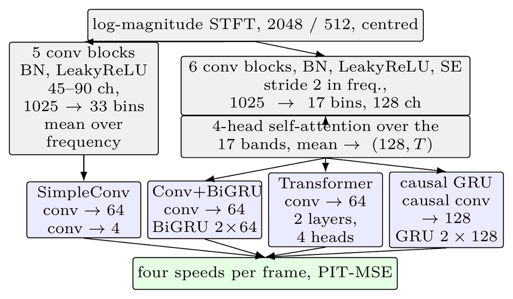

- Four compact networks on a log-magnitude STFT (2048 / 512).
- **SimpleConv** (0.54M): five strided conv blocks, mean over frequency, 1-D conv head.
- The other three (1.5–1.6M) share a trunk of six conv blocks with squeeze-and-excitation and a self-attention pool over the 17 surviving bands, then differ in the head: **Conv+BiGRU**, **Transformer** (2 layers), **causal GRU** (causal in the head only).
- **Loss: PIT-MSE.** Rotor indices are arbitrary; the first multichannel experiment showed why: fixed-index $R^2 = -0.78$, the same predictions under the optimal permutation $R^2 = 0.94$.
- All four are kept because the ranking of the 26-variant search did not survive a change of split.

**What we claim:** Claim: one common stem, different heads; PIT-MSE is justified because rotor indexing is arbitrary and the initial multi-microphone experiments showed it is necessary.

## 3. Baselines and the overall comparison

| Family | Method | zero | <30 | ramp | cruise DR | cruise FL | all |
| --- | --- | --- | --- | --- | --- | --- | --- |
| Classical (multi-pitch) | NMF harmonic dictionary | 83.7 | 63.3 | 27.6 | 11.6 | 17.8 | 26.4 |
|  | OT inverse harmonic clustering | 69.2 | 49.1 | 18.7 | 14.4 | 18.6 | 24.2 |
| Blind tracker (ours) | no refusal gates | 79.4 | 60.1 | 15.3 | **0.92** | 9.19 | 17.1 |
|  | gates + refusal → 0 | **0.01** | 23.4 | 56.8 | 28.2 | 70.4 | 39.8 |
| Multi-pitch L0, R4 (warm-up) | HPPNet | 17.5 | 17.5 | 21.0 | 3.81 | 1.63 | 7.77 |
|  | HarmoF0 | 14.8 | 18.9 | 20.4 | 11.5 | 1.92 | 10.8 |
|  | LateDeep | 52.6 | 35.6 | 16.8 | 2.96 | 4.46 | 12.6 |
|  | Basic Pitch | 33.9 | 38.7 | 24.4 | 26.4 | 25.6 | 27.3 |
| Regression, R3 | SimpleConv | 4.37 | **8.06** | 4.36 | 2.27 | 1.30 | **2.77** |
|  | Conv+BiGRU | 4.46 | 9.07 | 3.88 | 2.15 | 2.27 | 2.96 |
|  | Transformer | 4.91 | 14.9 | 4.58 | 2.42 | 1.48 | 3.23 |
|  | causal GRU | 6.82 | 16.3 | 5.91 | 2.15 | 2.28 | 3.80 |
| Multi-pitch L2, R4 (warm-up) | Basic Pitch | 0.50 | 18.0 | 39.1 | 43.9 | 9.47 | 27.6 |
|  | LateDeep | 4.98 | 15.8 | 8.61 | 2.32 | 1.69 | 3.83 |
|  | HarmoF0 | **0.09** | **11.5** | **3.21** | 2.98 | 1.07 | 2.45 |
|  | HPPNet | 1.07 | 14.6 | 3.63 | **2.07** | **0.77** | **2.27** |

PIT MAE (rev/s) on the frozen split, per frame regime. Colour: < 3 · 3–6 · 6–15 · ≥ 15.

- Classical (pYIN, cepstrum, HPS, matched comb, NMF, OT clustering): ≥ 24 rev/s over all frames; none can say “stopped”.
- **Blind tracker** (ours; DP comb search + phase-increment Kalman): best DREGON cruise, 0.92, but 9.2 on FLY124 and 40× the cost.
- Multi-pitch models at **L0** (published readout: one shared salience map, threshold + Hungarian): 2–10× worse than the regressors.
- **Why:** the shared map has an *oracle floor* of 8.2 rev/s on our data (55 % of frames have a rotor pair < 1 Hz apart). **L2** = four per-rotor layers + CRF readout, front end untouched → HPPNet 7.8 → **2.27**, HarmoF0 10.8 → **2.45**: on par with or ahead of the regressors.

**What we claim:** Claim: our simple regressors beat all the diverse baselines (classical + L0 multi-f0) by a margin, with the narrow exception of one blind tracker which is our invention — but (3½) salience models cannot even represent our ladder without modification, and the proper L1/L2 modifications bring them to parity with the regressors.

## 4. Generalization across microphones and drones

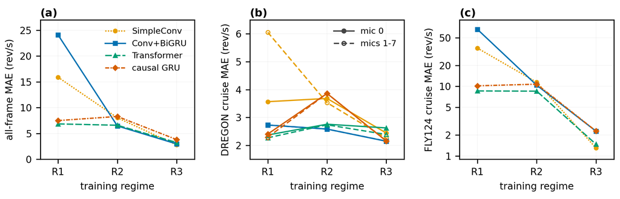

**Microphones (R1 → R2).** Trained on channel 0 only, the recurrent and attention models score the same on channels 1–7 as on channel 0 (2.73/2.73, 2.37/2.27, 2.40/2.29). Only SimpleConv pays (3.56 → 6.06).

**Drones (R2 → R3).** Every R1/R2 model fails on FLY124 (cruise 8.5–66 rev/s, octave-scale) although the cruise bands overlap. One flight of the second drone brings it to 1.3–2.3. This is transfer across *flights*, not airframes: first motivation for synthetic data.

**What we claim:** Claim: R1→R3 — only SimpleConv fails to generalize to unseen microphones, but all models fail to generalize across drones after seeing only one drone. One motivation for synthetic data.

## 5. What the models actually use: frequency-scaling probe

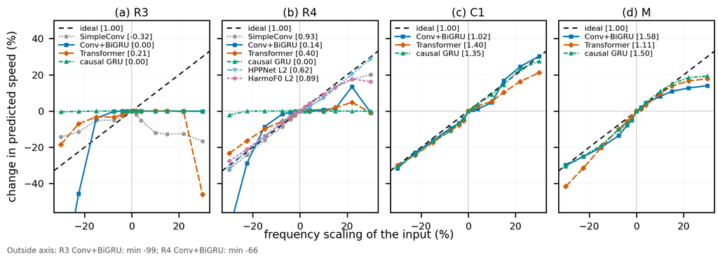

Resample six cruise clips by α; a model that reads the comb must scale its answer by α (slope 1). **R3:** every regressor is flat (local slopes −0.3 to 0.2), i.e. they recognise trajectories, they do not read frequency. **R4** (labels transformed with the audio): slopes 0.5–1.0 from step 0, 0.0–0.4 after a warm-up; HPPNet L2 0.62, HarmoF0 L2 0.89. **C1 / M** (comb curriculum / pool): 1.0–1.6. The probe cannot tell loudness, envelope and speed prior apart; it only says whether the harmonics are used.

**What we claim:** Claim: our methods never learned to actually track frequencies (flat frequency-shift response on R3); freq-scaling and time-warp augmentations (R4) make the models at least react to frequency scaling.

## 6. Synthetic rotor noise: generators and regimes

| regime | trunk | real all | DR cruise | FL cruise | comb | comb+speech | stoch | stoch+speech |
| --- | --- | --- | --- | --- | --- | --- | --- | --- |
| R3 | SimpleConv | 2.77 | 2.27 | 1.30 | 31.5 | 28.6 | 25.1 | 24.8 |
|  | Conv+BiGRU | 2.96 | 2.15 | 2.27 | 39.7 | 37.8 | 28.2 | 28.3 |
|  | Transformer | 3.23 | 2.42 | 1.48 | 28.1 | 26.3 | 27.3 | 26.8 |
|  | causal GRU | 3.80 | 2.15 | 2.28 | 29.1 | 26.8 | 28.8 | 29.4 |
| R4 | SimpleConv† | 3.28 | 2.93 | 2.00 | 10.9 | 10.6 | 22.9 | 23.1 |
|  | Conv+BiGRU | 2.77 | 2.62 | 1.25 | 21.7 | 18.5 | 27.2 | 26.7 |
|  | Transformer | 3.21 | 2.79 | **1.21** | 18.1 | 15.3 | 31.4 | 30.8 |
|  | causal GRU | 4.22 | **2.13** | 3.64 | 46.7 | 45.4 | 29.7 | 30.2 |
| S1 | Conv+BiGRU | 59.3 | 79.7 | 59.0 | **0.83** | **0.87** | 37.3 | 37.3 |
|  | Transformer | 60.1 | 77.7 | 66.9 | 1.34 | 1.42 | 37.3 | 37.3 |
|  | causal GRU | 58.5 | 77.8 | 61.1 | 0.91 | 0.93 | 37.6 | 37.5 |
| S2 | Conv+BiGRU | 34.8 | 45.0 | 35.1 | 11.4 | 10.7 | 4.21 | 4.09 |
|  | Transformer | 30.2 | 37.0 | 30.4 | 5.88 | 5.54 | 3.90 | 3.86 |
|  | causal GRU | 31.8 | 40.5 | 30.8 | 16.7 | 15.7 | **3.58** | **3.52** |
| C1 | Conv+BiGRU | **2.74** | 2.92 | 1.24 | 15.4 | 14.1 | 28.1 | 28.5 |
|  | Transformer | 3.37 | 2.65 | 1.43 | 10.4 | 9.19 | 28.4 | 27.8 |
|  | causal GRU | 3.61 | 3.16 | 1.45 | 24.1 | 20.7 | 30.4 | 30.1 |
| C2 | Conv+BiGRU | 3.12 | 3.23 | 1.58 | 16.3 | 14.3 | 34.1 | 34.2 |
| M | Conv+BiGRU | 6.05 | 2.88 | 5.31 | 4.88 | 4.79 | 10.9 | 11.4 |
|  | Transformer | 7.43 | 4.87 | 7.73 | 4.94 | 5.37 | 18.9 | 19.6 |
|  | causal GRU | 5.88 | 3.39 | 3.75 | 3.26 | 3.24 | 14.0 | 14.8 |

**Static comb:** coherent sinusoids at $k\,r_i(t)$, frequency structure only (15–25 dB in-octave contrast vs 7–8 dB real). **Stochastic comb:** Lorentzian lines with order-dependent width, GP-varying powers and floor, from phase measurements on the recordings (7–8 dB contrast).

**S1/S2** comb only · **C1/C2** comb then R4 · **M** one pool 2:1:1.

- No transfer either way: real-trained 9–47 on combs; comb-trained 30–60 on real.
- Curriculum helps a bit (C1 Conv+BiGRU 2.74 vs 2.77) and is where the models start to follow frequency.
- Pooling (M) transfers to both synthetic families but costs 5.9–7.4 on real; budget-truncated runs.
- Speech at eval time: ×1.8–2.2 without speech mixing, ×1.0–1.1 with.

**What we claim:** Claim: static comb = simple rotor noise without amplitude cues; stochastic comb = statistically closer to real drone noise. S1/S2/C1/C2/M cross-validation: models do not transfer from synthetic to real data, but curriculum training helps a bit.

## 7. What the predictions look like

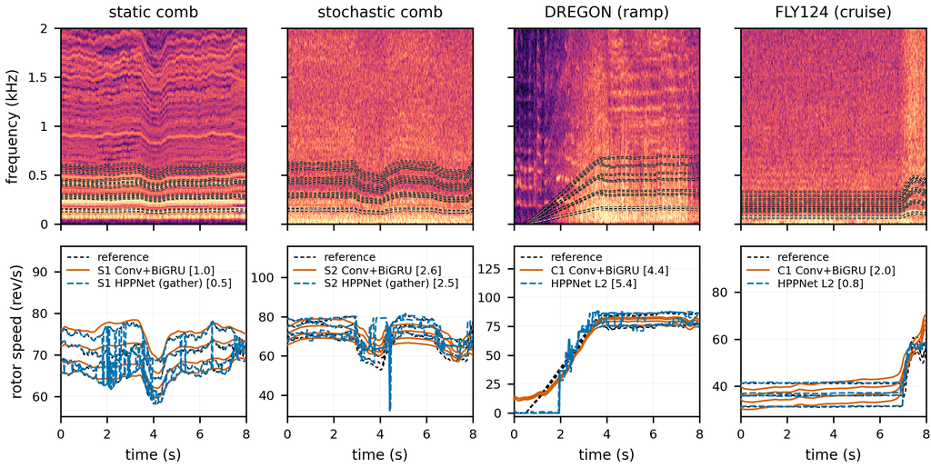

Best regressor and best salience model trained on each family. **Regressors** regress to the mean comb: near-unison rotors merge, and on the stochastic comb the predicted spread is 5–6 rev/s whatever the truth (0.4–22). **Salience models** keep rotors apart but *jump*: octave locks, wandering on ramps, nothing below the grid. Both lose the take-off/landing ramps, where the labels are weakest. Remedies (future work): a multimodal readout on the regressor trunk; a joint decoder or the tracker’s phase refinement on the L2 tracks.

**What we claim:** Claim: overlaying the best models on ground truth (static comb, stochastic comb, DREGON, MD2) shows regression to the comb-over-mean for regressors and noisy jumps for salience models; we propose mitigations as future work.

## Where this stands

**Problems with the current results**

- **Regimes are not unified.** The L0/L2 salience rows and the “R4” regressors were trained on the R4-with-warm-up recipe; the ladder rows on R3. Table III has two regressor blocks for that reason.
- **Undertrained rows.** The M regime was budget-truncated (25–34 epochs); early-stopping schedules differed across the campaign. Salience rows used batch 16, regressors 128 (8–10× more steps at equal frames).
- **Single seeds everywhere.** C1 vs R4 is within seed noise; HarmoF0 L2 sits on a noisy plateau.
- **L1 for the ports** (HarmoF0, HPPNet) is defined but not run, so the L0 → L2 gain is not decomposed.
- Two drones only; DREGON labels carry a 0.3–0.7 rev/s floor; the blind tracker is our own baseline.
- The draft is 11 pages against OJSP’s 8 + 1.

**Plan**

1. Unified-regime reruns are in the queue (A100 batch, fixed schedule, one recipe for every row). Tables and figures regenerate from scripts; the prose is written to survive the numbers changing.
2. Rerun M to patience, run the two L1 rows, add a second seed for the headline rows if the budget allows.
3. Trim to 8 pages (subsection headings and the two large tables are the cost).
4. Target: **IEEE OJSP if the reruns hold up** — i.e. if L2 stays on par with the regressors and the R3 → R4 → C1 story survives.